# STAT 512 Division 1 HW 7

Yi Yang

12/3/2018

1. A soft drink manufacturer uses five agents to handle premium distributions for its various products. The marketing director desired to study the timeliness with which the premiums are distributed. Twenty transactions for each agent were selected at random, and the time lapse (in days) for handling each transaction was determined. The results are in premium.txt.

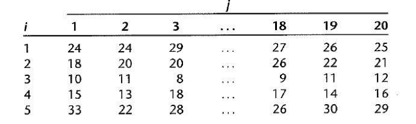

1. Use aligned box plots to compare the factor level means. Do they appear to be different? Does the variability of the observations within each factor level appear to be approximately the same for all factor levels?
2. Obtain the fitted values.
3. Obtain the residues. Do they sum to zero as in the regression model?
4. Obtain the analysis of variance table.
5. Test whether or not the mean time lapse differs for the five agents; use $\alpha = 0.1$. State the alternatives, decision rule, and conclusion.
6. Test assumption for the test.

**Solution:**

```r
premium <- read.table('premium.txt', header = FALSE)
library('ggpubr')
```

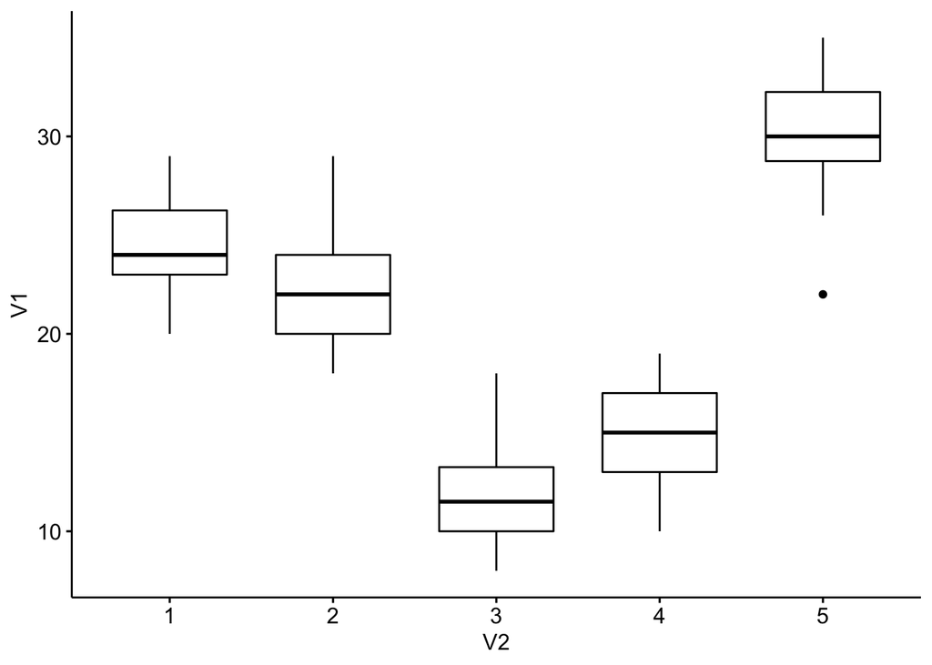

```r
ggboxplot(premium,x='V2', y='V1')
```

```r
premium$design <- as.factor(premium$V2)
premium$y <- premium$V1
premium$x1 <- c(rep(1,20),rep(0,60),rep(-1,20))
premium$x2 <- c(rep(0,20),rep(1,20),rep(0,40),rep(-1,20))
premium$x3 <- c(rep(0,40),rep(1,20),rep(0,20),rep(-1,20))
premium$x4 <- c(rep(0,60),rep(1,20),rep(-1,20))

premium.mod <- lm(y~x1+x2+x3+x4,premium)
summary(premium.mod)
```

```
##
## Call:
## lm(formula = y ~ x1 + x2 + x3 + x4, data = premium)
##
## Residuals:
##    Min     1Q Median     3Q    Max
## -8.100 -1.762 -0.325  1.975  6.450
##
## Coefficients:
##             Estimate Std. Error t value Pr(>|t|)
## (Intercept)  20.7500     0.2743  75.654  < 2e-16 ***
## x1            3.8000     0.5485   6.927 5.08e-10 ***
## x2            1.8000     0.5485   3.281  0.00145 **
## x3           -9.0000     0.5485 -16.407  < 2e-16 ***
## x4           -5.9500     0.5485 -10.847  < 2e-16 ***
## ---
## Signif. codes:  0 '***' 0.001 '**' 0.01 '*' 0.05 '.' 0.1 ' ' 1
##
## Residual standard error: 2.743 on 95 degrees of freedom
## Multiple R-squared:  0.8611, Adjusted R-squared:  0.8552
## F-statistic: 147.2 on 4 and 95 DF,  p-value: < 2.2e-16
```

```r
#summary(lm(y~design, premium))
```

Above code implies $\mu_1 = 24.55, \mu_2 = 22.55, \mu_3 = 11.75, \mu_4 = 14.8$ and $\mu_5 = 30.1$. The population mean is $\mu_{.} = 20.75$

3. The residues are given below. They do sum to zero.

```r
res <- premium$y - c(rep(24.55,20),rep(22.55,20),rep(11.75,20),rep(14.8,20),rep(30.1,20))
res
```

```
##   [1] -0.55 -0.55  4.45 -4.55 -3.55  0.45  3.45  2.45 -1.55 -3.55 -0.55
##  [12]  1.45 -1.55 -0.55  3.45 -1.55 -1.55  2.45  1.45  0.45 -4.55 -2.55
##  [23] -2.55  1.45 -0.55  6.45  0.45  1.45  5.45 -3.55  1.45  2.45 -1.55
##  [34] -2.55  1.45 -0.55 -3.55  3.45 -0.55 -1.55 -1.75 -0.75 -3.75  0.25
##  [45]  0.25 -1.75  2.25 -2.75 -3.75 -0.75  4.25  0.25  6.25  2.25  1.25
##  [56] -0.75  2.25 -2.75 -0.75  0.25  0.20 -1.80  3.20  1.20 -2.80  4.20
##  [67] -4.80  3.20 -3.80  2.20  0.20 -2.80 -1.80 -1.80 -0.80  2.20  1.20
##  [78]  2.20 -0.80  1.20  2.90 -8.10 -2.10  4.90 -1.10 -2.10 -0.10  0.90
##  [89] -1.10 -2.10  2.90 -0.10  1.90  2.90 -1.10  4.90  1.90 -4.10 -0.10
## [100] -1.10
```

```r
sum(res)
```

```
## [1] -7.105427e-14
```

4. The ANOVA table is given by

```r
anova(premium.mod)
```

```
## Analysis of Variance Table
##
## Response: y
##           Df  Sum Sq Mean Sq F value    Pr(>F)
## x1         1  308.02  308.02  40.946 5.883e-09 ***
## x2         1  304.01  304.01  40.413 7.122e-09 ***
## x3         1 2933.00 2933.00 389.891 < 2.2e-16 ***
## x4         1  885.06  885.06 117.653 < 2.2e-16 ***
## Residuals 95  714.65    7.52
## ---
## Signif. codes:  0 '***' 0.001 '**' 0.01 '*' 0.05 '.' 0.1 ' ' 1
```

5. The test is stated as
   $$H_0: \tau_1 = \tau_2=\dots=\tau_5 = 0;\quad H_a: \text{at least one } \tau_i \text{ is nonzero}$$
   Based on F test, the test statistic is $Ts = \frac{MSR(X_1,X_2,X_3,X_4)}{MSE} = \frac{1107.5225}{7.52} = 147.28 > 2.004$. The null hypothesis is rejected, the mean time differs.

```r
qf(1-0.1,4,95)
```

```
## [1] 2.004992
```

6. The test assumption is that the error is assumed to be normally distributed with constant variance.
2. Refer to problem 1, suppose that 25 percent of all premium distribution are handled by agent 1, 20 percent by agent 2, 20 percent by agent 3, 20 percent by agent 4, and 15 percent by agent 5.
1. Obtain a point estimate of the grand mean $\mu$. When the ANOVA model is expressed in the factor effects with the weights being the proportions of premium distribution handled by each agent.
   $$\mu. = \sum w_i\mu_i$$
2. Test whether or not the mean lapse differs for the five agents; use = 0.1. State the alternatives, decision rule, and conclusion.

**Solution:**

```r
premium$x11 <- c(rep(1,20),rep(0,60),rep(-4/3,20))
premium$x22 <- c(rep(0,20),rep(1,20),rep(0,40),rep(-4/3,20))
premium$x33 <- c(rep(0,40),rep(1,20),rep(0,20),rep(-4/3,20))
premium$x44 <- c(rep(0,60),rep(1,20),rep(-4/3,20))

premium.mod1 <- lm(y~x11+x22+x33+x44,premium)
summary(premium.mod1)
```

```
##
## Call:
## lm(formula = y ~ x11 + x22 + x33 + x44, data = premium)
##
## Residuals:
##    Min     1Q Median     3Q    Max
## -8.100 -1.762 -0.325  1.975  6.450
##
## Coefficients:
##             Estimate Std. Error t value Pr(>|t|)
## (Intercept)  20.2579     0.2758  73.454  < 2e-16 ***
## x11           4.2921     0.5421   7.918 4.47e-12 ***
## x22           2.2921     0.5421   4.229 5.41e-05 ***
## x33          -8.5079     0.5421 -15.696  < 2e-16 ***
## x44          -5.4579     0.5421 -10.069  < 2e-16 ***
## ---
## Signif. codes:  0 '***' 0.001 '**' 0.01 '*' 0.05 '.' 0.1 ' ' 1
##
## Residual standard error: 2.743 on 95 degrees of freedom
## Multiple R-squared:  0.8611, Adjusted R-squared:  0.8552
## F-statistic: 147.2 on 4 and 95 DF,  p-value: < 2.2e-16
```

2. The test is stated as
   $$H_0: \tau_1 = \tau_2=\dots=\tau_5 = 0;\quad H_a: \text{at least one } \tau_i \text{ is nonzero}$$
   Based on F test, the test statistic is $Ts = \frac{MSR(X_1,X_2,X_3,X_4)}{MSE} = \frac{1107.525}{7.52} = 147.28 > 2.004$. The null hypothesis is rejected, the mean time differs.

```r
anova(premium.mod1)
```

```
## Analysis of Variance Table
##
## Response: y
##           Df  Sum Sq Mean Sq F value    Pr(>F)
## x11        1  545.16  545.16  72.469 2.472e-13 ***
## x22        1  323.41  323.41  42.992 2.849e-09 ***
## x33        1 2798.86 2798.86 372.058 < 2.2e-16 ***
## x44        1  762.67  762.67 101.384 < 2.2e-16 ***
## Residuals 95  714.65    7.52
## ---
## Signif. codes:  0 '***' 0.001 '**' 0.01 '*' 0.05 '.' 0.1 ' ' 1
```

```r
qf(1-0.1,4,95)
```

```
## [1] 2.004992
```

3. Refer to problem 1.
1. Construct a $90\%$ confidence interval for the mean time lapse for agent 1.
2. Obtain a $90\%$ confidence interval for $\mu_2 - \mu_1$. Interpret your interval estimate.
3. The marketing director wishes to compare the mean time lapses for agents 1, 3, and 5. Obtain confidence interval for all pairwise comparisons among these three treatment means; use the Bonferroni procedure with a $90\%$ family level.

**Solution:**

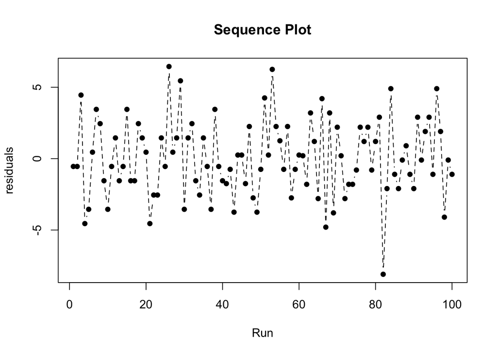

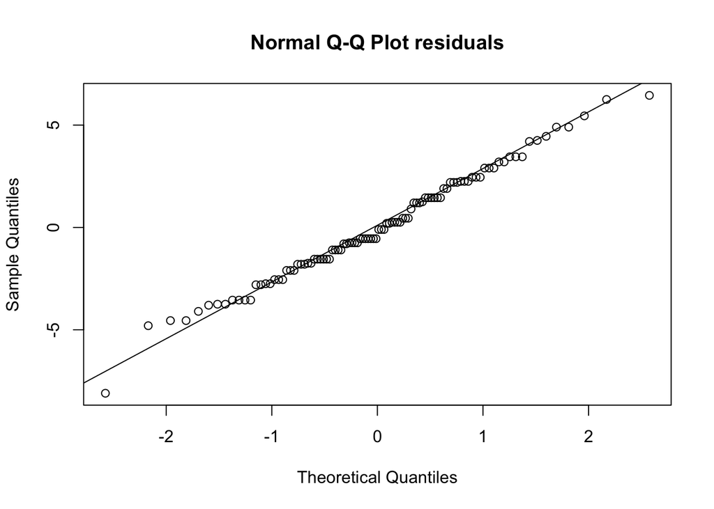

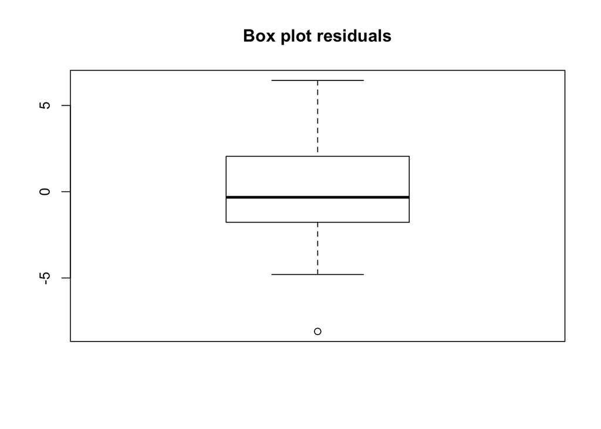

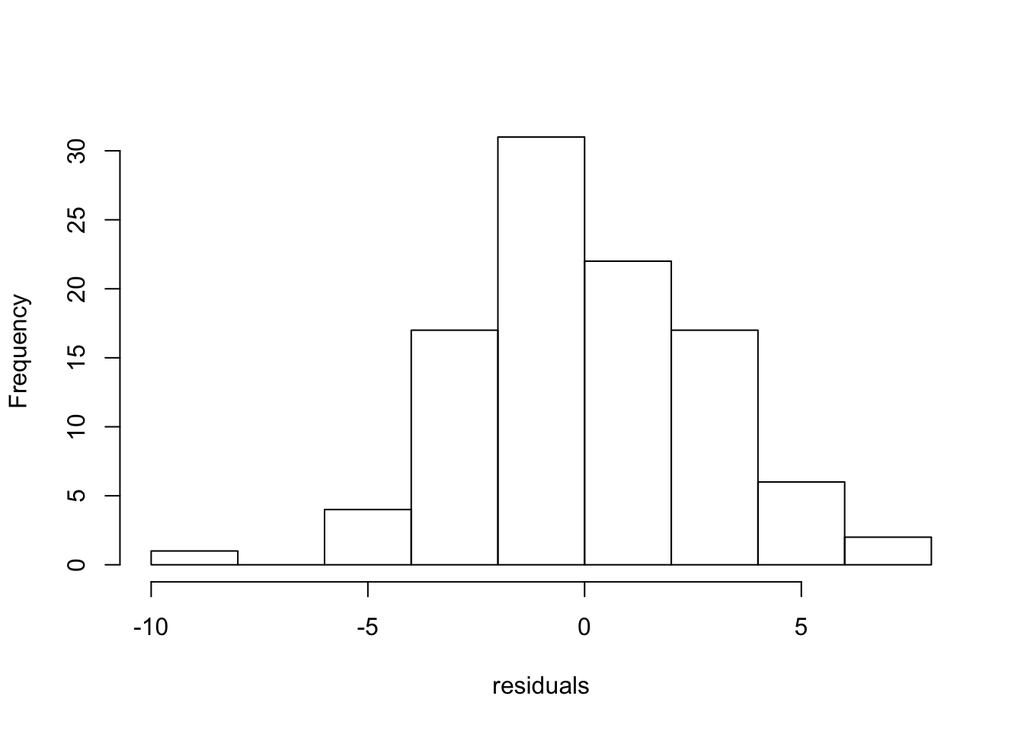

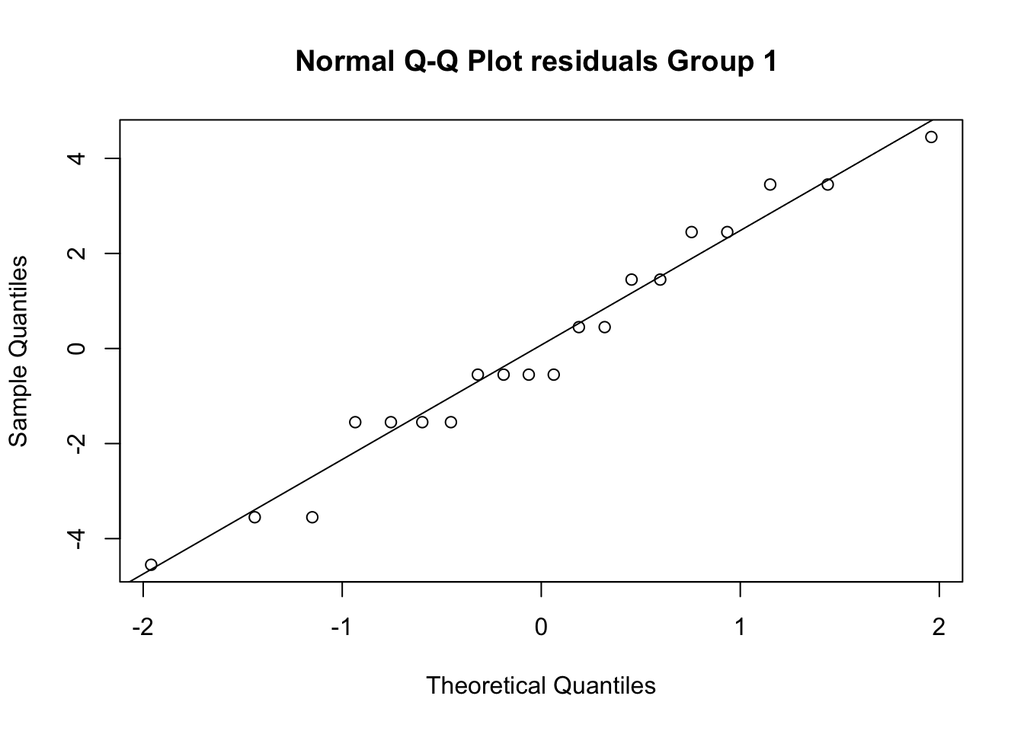

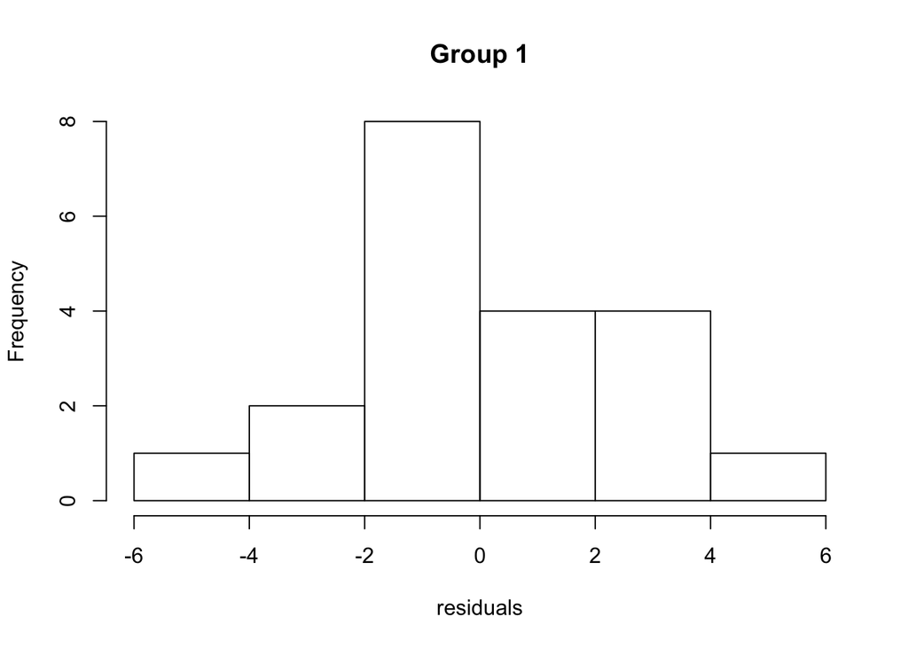

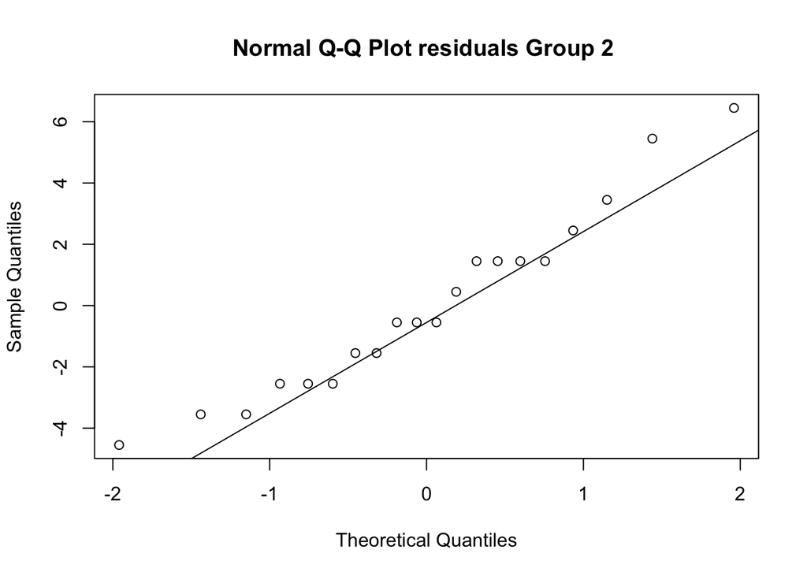

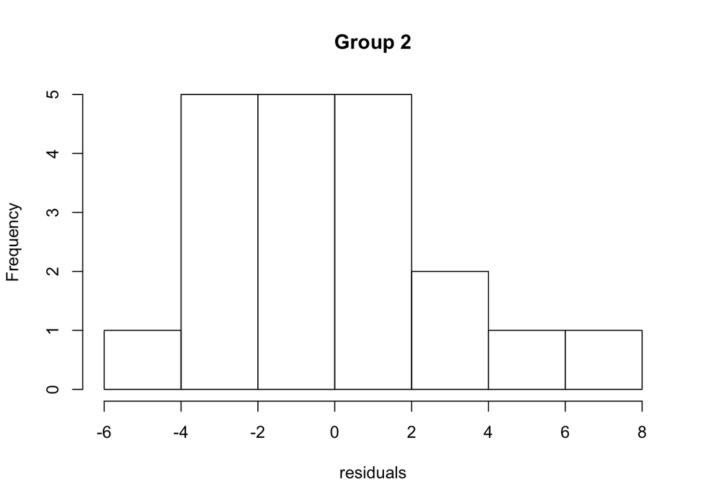

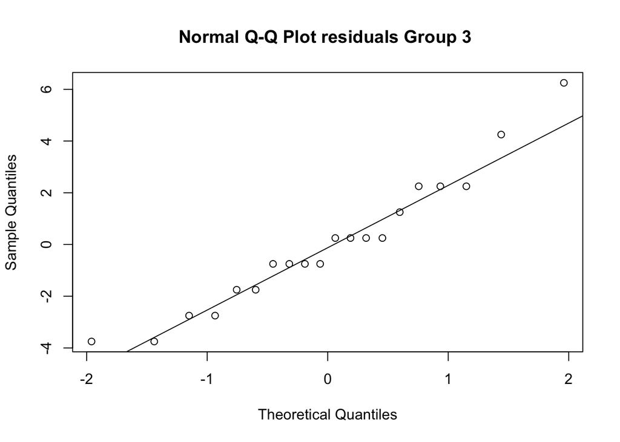

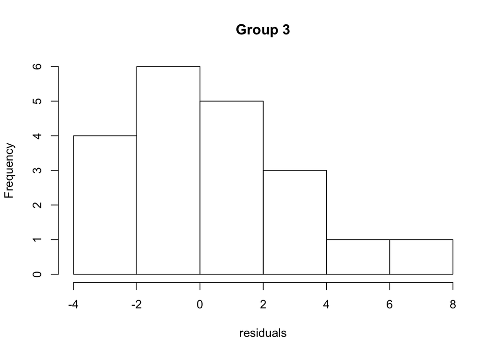

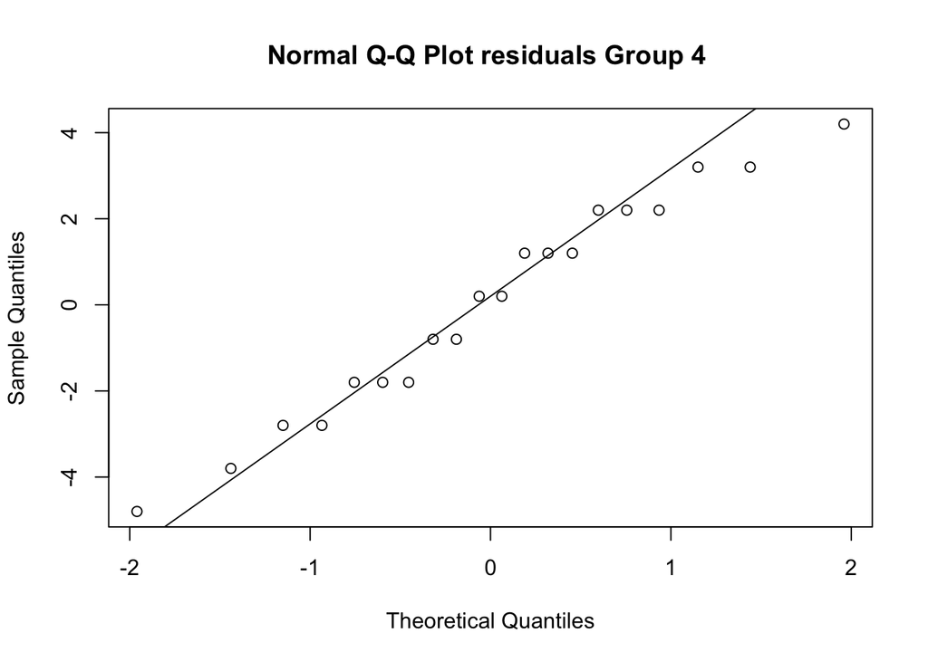

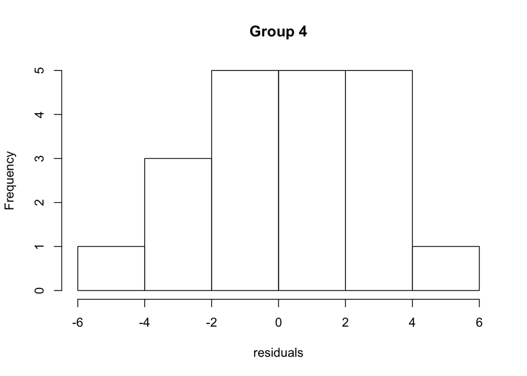

[15 more figures not shown]

```
##        L    lower    upper        t  p-value
## 24.55000 23.53128 25.56872 40.02963  0.00000
```

```r
library(ALSM)
oneway(premium$y,premium$design,alpha = 0.1, mc=matrix(c(1,0,0,0,0),1,5))$Contrast.NOT.simultaneous
```

4. Refer to problem 1, suppose primary interest is in estimating the following comparisons:
   $$L_1 = \frac{\mu_1 + \mu_2}{2} - \mu_5$$
   $$L_2 = \frac{\mu_1 + \mu_2}{2} - \frac{(\mu_3 + \mu_4)}{2}$$
   a)Obtain a $90\%$ confidence interval for individual comparision.
2. Obtain a $90\%$ simultaneous confidence interval for the two comparisons.
5. A computer software firm was encountering difficulties in forcasting the programmer requirements for large-O scale programming projects. Twenty-four programmers are classified into equal groups by type of experience (factor A) and amount of experience (factor B) were asked to predict the number of programmer days required to complete a large project about to be initiated. After this project was completed, the prediction errors (actual minus predicted programmer-days) were determined. The data is in programmer.txt

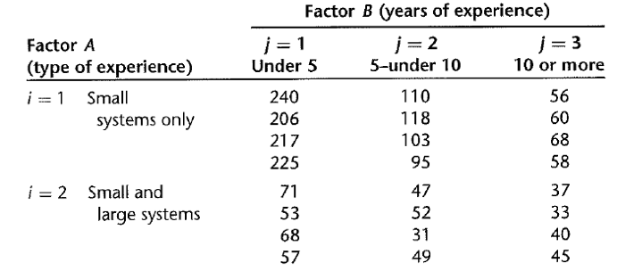

1. Prepare an estimated means plot. Does your graph suggest that any main factor or interaction effects are present? Explain.
2. Obtain the ANOVA table. Does any one source account for most of the total variability?
3. Test whether the two factors interact; use 0.01 significant level.
4. Test whether the main effects are present, use 0.01 significant level.

6.Refer to question 5.

1. Estimate $\mu_{23}$ with 99 percent confidence interval. Interpret your estimate.
2. Estimate $D = \mu_{12} - \mu_{13}$ with $99\%$ confidence interval. Interpret your estimate.
3. The nature of the interaction effects is to be studied by comparing the effects of type of experience for each yours-of-experience group. Specifically, the following comparisons are to be estimated:
   $$L_1 = (\mu_{11} - \mu_{21}) - (\mu_{12} - \mu_{22})$$
   $$L_2 = (\mu_{11} - \mu_{21}) - (\mu_{13} - \mu_{23})$$
   $$L_3 = (\mu_{12} - \mu_{22}) - (\mu_{13} - \mu_{23})$$
   Obtain a simultaneous confidence interval, with $95\%$ level.
4. To examine whether a transformation of the data would make the interaction unimportant, plot separately the transformed estimated means for the reciprocal (1/Y) and logarithmic transformation ($\log Y$). Would either of these transformations have made the interaction effects unimportant?